# Lab 4

Due: 10/24/2019 by 10 pm

Aashwin Lamsal, Eric Friesth

10/24/2019

Some abbreviations for the column names can be found in the Glossaries sheet in the Excel file.

**References:**

- [Iowa State University Athelete](https://cyclones.com/index.aspx)
- [A Beginner’s Guide to American Football](https://www.youtube.com/watch?v=3t6hM5tRlfA) for the rules of American football.

## Loading Data: Cyclone Football

```r
library(readxl)
defense <- read_excel('cyclonesFootball2018.xlsx', sheet='Defensive')
str(defense)
```

```
## Classes 'tbl_df', 'tbl' and 'data.frame':    446 obs. of  11 variables:
##  $ Name             : chr  "Eisworth, Greg" "Eisworth, Greg" "Eisworth, Greg" "Eisworth, Greg" ...
##  $ Opponent_Opponent: chr  "Iowa" "Oklahoma" "Akron" "TCU" ...
##  $ Tackles_Solo     : chr  "3" "6" "7" "6" ...
##  $ Tackles_ASST     : chr  "3" "8" "2" "3" ...
##  $ Tackles_TFL      : chr  "0" "1.0" "1.0" "0" ...
##  $ Tackles_Sack     : chr  "0" "0" "0" "0" ...
##  $ Turnover_FF      : chr  "0" "1" "0" "0" ...
##  $ Turnover_FR      : chr  "0" "0" "0" "0" ...
##  $ Turnover_INT     : chr  "0" "0" "0" "0" ...
##  $ Pass_QBH         : chr  "0" "0" "0" "0" ...
##  $ Pass_PB          : chr  "0" "0" "3" "0" ...
```

## Part one: Cleaning data

-The player names and opponent names are factors. -All offensive and defensive statistics are numerical. The `Weight` column in Biography is also numeric.  
-Separate the `Height` column into two columns. The newly created columns must be numeric. Then we create one column that  
represents `Height`, dropping the irrelevant columns in the process.

we are then left with three clean data frames: `defClean`, `offClean`, and `bioClean` with the structures of each being printed below.

```r
library(tidyverse)
library(dplyr)
#Part1: player names and opponent names are factors
offense$Name <- factor(offense$Name)
defense$Name <- factor(defense$Name)

offense$Opponent_Opponent <- factor(offense$Opponent_Opponent)
defense$Opponent_Opponent <- factor(defense$Opponent_Opponent)

str(offense) #checking to see if the changes were made successfully
```

```
## Classes 'tbl_df', 'tbl' and 'data.frame':    168 obs. of  12 variables:
##  $ Name             : Factor w/ 15 levels "Akers, Landen",..: 6 6 6 6 6 6 6 6 6 6 ...
##  $ Opponent_Opponent: Factor w/ 13 levels "Akron","Baylor",..: 4 7 1 9 8 13 11 5 2 10 ...
##  $ Receiving_REC    : chr  "1" "9" "6" "3" ...
##  $ Receiving_YDS    : chr  "31" "66" "39" "23" ...
##  $ Receiving_TD     : chr  "0" "0" "0" "0" ...
##  $ Rushing_ATT      : chr  NA NA NA NA ...
##  $ Rushing_YDS      : chr  NA NA NA NA ...
##  $ Rushing_TD       : chr  NA NA NA NA ...
##  $ Passing_CMP-ATT  : chr  NA NA NA NA ...
##  $ Passing_YDS      : chr  NA NA NA NA ...
##  $ Passing_TD       : chr  NA NA NA NA ...
##  $ Passing_INT      : chr  NA NA NA NA ...
```

```r
str(defense)
```

```
## Classes 'tbl_df', 'tbl' and 'data.frame':    446 obs. of  11 variables:
##  $ Name             : Factor w/ 42 levels "Akers, Landen",..: 7 7 7 7 7 7 7 7 7 7 ...
##  $ Opponent_Opponent: Factor w/ 13 levels "Akron","Baylor",..: 4 7 1 9 8 13 11 5 2 10 ...
##  $ Tackles_Solo     : chr  "3" "6" "7" "6" ...
##  $ Tackles_ASST     : chr  "3" "8" "2" "3" ...
##  $ Tackles_TFL      : chr  "0" "1.0" "1.0" "0" ...
##  $ Tackles_Sack     : chr  "0" "0" "0" "0" ...
##  $ Turnover_FF      : chr  "0" "1" "0" "0" ...
##  $ Turnover_FR      : chr  "0" "0" "0" "0" ...
##  $ Turnover_INT     : chr  "0" "0" "0" "0" ...
##  $ Pass_QBH         : chr  "0" "0" "0" "0" ...
##  $ Pass_PB          : chr  "0" "0" "3" "0" ...
```

```r
#Part 2: All offensive and defensive statistics are numerical. The `Weight` column in Biography is also numeric. (Hint: look at `?mutate_at` if you want to save writing some code).

offClean<- offense %>% mutate_at(c("Receiving_REC","Receiving_YDS","Receiving_TD","Rushing_ATT","Rushing_YDS", "Rushing_TD", "Passing_CMP-ATT", "Passing_YDS", "Passing_TD", "Passing_INT"), funs(as.numeric), na.rm=TRUE)
str(offClean) #checking if changes were made successfully
```

```
## Classes 'tbl_df', 'tbl' and 'data.frame':    168 obs. of  12 variables:
##  $ Name             : Factor w/ 15 levels "Akers, Landen",..: 6 6 6 6 6 6 6 6 6 6 ...
##  $ Opponent_Opponent: Factor w/ 13 levels "Akron","Baylor",..: 4 7 1 9 8 13 11 5 2 10 ...
##  $ Receiving_REC    : num  1 9 6 3 6 1 1 4 4 0 ...
##  $ Receiving_YDS    : num  31 66 39 23 37 32 4 31 39 0 ...
##  $ Receiving_TD     : num  0 0 0 0 1 1 0 0 1 0 ...
##  $ Rushing_ATT      : num  NA NA NA NA NA NA NA NA NA NA ...
##  $ Rushing_YDS      : num  NA NA NA NA NA NA NA NA NA NA ...
##  $ Rushing_TD       : num  NA NA NA NA NA NA NA NA NA NA ...
##  $ Passing_CMP-ATT  : num  NA NA NA NA NA NA NA NA NA NA ...
##  $ Passing_YDS      : num  NA NA NA NA NA NA NA NA NA NA ...
##  $ Passing_TD       : num  NA NA NA NA NA NA NA NA NA NA ...
##  $ Passing_INT      : num  NA NA NA NA NA NA NA NA NA NA ...
```

```r
defClean<- defense %>% mutate_at(c("Tackles_Solo", "Tackles_ASST", "Tackles_TFL","Tackles_Sack","Turnover_FF", "Turnover_FR", "Turnover_INT", "Pass_QBH", "Pass_PB"), funs(as.numeric), na.rm=TRUE)

str(defClean)#checking if changes were made successfully
```

```
## Classes 'tbl_df', 'tbl' and 'data.frame':    446 obs. of  11 variables:
##  $ Name             : Factor w/ 42 levels "Akers, Landen",..: 7 7 7 7 7 7 7 7 7 7 ...
##  $ Opponent_Opponent: Factor w/ 13 levels "Akron","Baylor",..: 4 7 1 9 8 13 11 5 2 10 ...
##  $ Tackles_Solo     : num  3 6 7 6 3 5 3 7 2 9 ...
##  $ Tackles_ASST     : num  3 8 2 3 0 3 2 1 4 3 ...
##  $ Tackles_TFL      : num  0 1 1 0 1 1 0 0 0 0 ...
##  $ Tackles_Sack     : num  0 0 0 0 0 1 0 0 0 0 ...
##  $ Turnover_FF      : num  0 1 0 0 0 0 0 0 0 1 ...
##  $ Turnover_FR      : num  0 0 0 0 0 0 0 0 0 0 ...
##  $ Turnover_INT     : num  0 0 0 0 0 0 1 0 0 0 ...
##  $ Pass_QBH         : num  0 0 0 0 0 0 0 0 0 0 ...
##  $ Pass_PB          : num  0 0 3 0 0 0 0 0 0 0 ...
```

```r
bio <- bio%>% mutate_at(c("Weight"), funs(as.numeric))
str(bio)
```

```
## Classes 'tbl_df', 'tbl' and 'data.frame':    123 obs. of  7 variables:
##  $ Name      : chr  "Akers, Landen" "Allen, Chase" "Alt, Gerry" "Anderson, Cole" ...
##  $ Position  : chr  "Wide Receiver" "Tight End" "Offensive Line" "Tight End" ...
##  $ Height    : chr  "6-0" "6-7" "6-2" "6-4" ...
##  $ Weight    : num  192 240 290 250 191 205 192 224 251 284 ...
##  $ Class     : chr  "Redshirt Sophomore" "Redshirt Sophomore" "Redshirt Freshman" "Redshirt Senior" ...
##  $ Hometown  : chr  "Cedar Rapids, Iowa" "Nixa, Mo." "Cedar Rapids, Iowa" "League City, Texas" ...
##  $ Highschool: chr  "Washington" "Nixa" "Washington" "Clear Falls" ...
```

```r
#Part 3: Separate the `Height` column into two columns. Make sure the newly created columns are numeric. Then create one column that represents `Height` (Hint: Use a unit that works well). Drop any irrelavant columns from this process

newBio = bio

bio_split = strsplit(as.character(newBio$Height), split = "-")
newBio = transform(newBio, Height_Feet = sapply(bio_split, "[[", 1), Height_Inches = sapply(bio_split, "[[", 2))
str(newBio)
```

```
## 'data.frame':    123 obs. of  9 variables:
##  $ Name         : chr  "Akers, Landen" "Allen, Chase" "Alt, Gerry" "Anderson, Cole" ...
##  $ Position     : chr  "Wide Receiver" "Tight End" "Offensive Line" "Tight End" ...
##  $ Height       : chr  "6-0" "6-7" "6-2" "6-4" ...
##  $ Weight       : num  192 240 290 250 191 205 192 224 251 284 ...
##  $ Class        : chr  "Redshirt Sophomore" "Redshirt Sophomore" "Redshirt Freshman" "Redshirt Senior" ...
##  $ Hometown     : chr  "Cedar Rapids, Iowa" "Nixa, Mo." "Cedar Rapids, Iowa" "League City, Texas" ...
##  $ Highschool   : chr  "Washington" "Nixa" "Washington" "Clear Falls" ...
##  $ Height_Feet  : Factor w/ 2 levels "5","6": 2 2 2 2 2 1 2 2 2 2 ...
##  $ Height_Inches: Factor w/ 12 levels "0","1","10","11",..: 1 10 5 7 1 4 1 6 5 5 ...
```

```r
#newBio = newBio %>% mutate_at(c("Height_Feet", "Height_Inches"), funs(as.numeric))

newBio= newBio%>% mutate(heightInFeet= as.numeric(as.character(newBio$Height_Feet))) #since splitting the height into 2 columns gives us two columns of factors, converting to character then numeric is a workaround for the type conversion error caused by directly converting from factor type
newBio= newBio%>% mutate(inchesInChar=as.numeric(as.character(newBio$Height_Inches)))

newBio= newBio%>% mutate(totalHeighInInches= (heightInFeet * 12) + inchesInChar) #new calculated column for total heights

newBio <- newBio%>% select(-c("Height_Feet","Height_Inches", "Highschool", "Height", "heightInFeet", "inchesInChar"))

str(newBio)
```

```
## 'data.frame':    123 obs. of  6 variables:
##  $ Name              : chr  "Akers, Landen" "Allen, Chase" "Alt, Gerry" "Anderson, Cole" ...
##  $ Position          : chr  "Wide Receiver" "Tight End" "Offensive Line" "Tight End" ...
##  $ Weight            : num  192 240 290 250 191 205 192 224 251 284 ...
##  $ Class             : chr  "Redshirt Sophomore" "Redshirt Sophomore" "Redshirt Freshman" "Redshirt Senior" ...
##  $ Hometown          : chr  "Cedar Rapids, Iowa" "Nixa, Mo." "Cedar Rapids, Iowa" "League City, Texas" ...
##  $ totalHeighInInches: num  72 79 74 76 72 71 72 75 74 74 ...
```

```r
bioClean = newBio


#Part 4: By cleaning the three data frames in R, at the end of this step you should have the following three clean data frames: `defClean`, `offClean`, and `bioClean`. Print the structures of these data frames. **Make sure your data types make sense for each variable.**

str(bioClean)
```

```
## 'data.frame':    123 obs. of  6 variables:
##  $ Name              : chr  "Akers, Landen" "Allen, Chase" "Alt, Gerry" "Anderson, Cole" ...
##  $ Position          : chr  "Wide Receiver" "Tight End" "Offensive Line" "Tight End" ...
##  $ Weight            : num  192 240 290 250 191 205 192 224 251 284 ...
##  $ Class             : chr  "Redshirt Sophomore" "Redshirt Sophomore" "Redshirt Freshman" "Redshirt Senior" ...
##  $ Hometown          : chr  "Cedar Rapids, Iowa" "Nixa, Mo." "Cedar Rapids, Iowa" "League City, Texas" ...
##  $ totalHeighInInches: num  72 79 74 76 72 71 72 75 74 74 ...
```

```r
str(defClean)
```

```
## Classes 'tbl_df', 'tbl' and 'data.frame':    446 obs. of  11 variables:
##  $ Name             : Factor w/ 42 levels "Akers, Landen",..: 7 7 7 7 7 7 7 7 7 7 ...
##  $ Opponent_Opponent: Factor w/ 13 levels "Akron","Baylor",..: 4 7 1 9 8 13 11 5 2 10 ...
##  $ Tackles_Solo     : num  3 6 7 6 3 5 3 7 2 9 ...
##  $ Tackles_ASST     : num  3 8 2 3 0 3 2 1 4 3 ...
##  $ Tackles_TFL      : num  0 1 1 0 1 1 0 0 0 0 ...
##  $ Tackles_Sack     : num  0 0 0 0 0 1 0 0 0 0 ...
##  $ Turnover_FF      : num  0 1 0 0 0 0 0 0 0 1 ...
##  $ Turnover_FR      : num  0 0 0 0 0 0 0 0 0 0 ...
##  $ Turnover_INT     : num  0 0 0 0 0 0 1 0 0 0 ...
##  $ Pass_QBH         : num  0 0 0 0 0 0 0 0 0 0 ...
##  $ Pass_PB          : num  0 0 3 0 0 0 0 0 0 0 ...
```

```r
str(offClean)
```

```
## Classes 'tbl_df', 'tbl' and 'data.frame':    168 obs. of  12 variables:
##  $ Name             : Factor w/ 15 levels "Akers, Landen",..: 6 6 6 6 6 6 6 6 6 6 ...
##  $ Opponent_Opponent: Factor w/ 13 levels "Akron","Baylor",..: 4 7 1 9 8 13 11 5 2 10 ...
##  $ Receiving_REC    : num  1 9 6 3 6 1 1 4 4 0 ...
##  $ Receiving_YDS    : num  31 66 39 23 37 32 4 31 39 0 ...
##  $ Receiving_TD     : num  0 0 0 0 1 1 0 0 1 0 ...
##  $ Rushing_ATT      : num  NA NA NA NA NA NA NA NA NA NA ...
##  $ Rushing_YDS      : num  NA NA NA NA NA NA NA NA NA NA ...
##  $ Rushing_TD       : num  NA NA NA NA NA NA NA NA NA NA ...
##  $ Passing_CMP-ATT  : num  NA NA NA NA NA NA NA NA NA NA ...
##  $ Passing_YDS      : num  NA NA NA NA NA NA NA NA NA NA ...
##  $ Passing_TD       : num  NA NA NA NA NA NA NA NA NA NA ...
##  $ Passing_INT      : num  NA NA NA NA NA NA NA NA NA NA ...
```

## Part two: Tidying

Next, to tidy the tables, we must reformat the `defClean` data frame into a tidy format by using `gather`. After this, we created a histogram for each defensive statistic, and used `facet_wrap` to draw all histograms in a single plot. Based on the distributions of the defensive skills below, we see that many of these skills are rare such as turnovers (specifically forced fumbles, fumble recovery, and interceptions) as well as tackles (specifically sacks).

We then moved onto the question of whether or not ISU had a better defense against West Virginia or Kansas State. We answered this question by creating a scatterplot with x-axis being the name of each player, the y-axis the number of solo tackles each player made, and our color coding indicating which points represent the Kansas State and West Virginia games respectively (please excuse us for this is not exactly what the question was asking for, we ended up getting really stuck here to be quite honest). A large number of solo tackles indicates good defense, and juding from the scatter plot we made below, we observed the number of solo tackles made by each player on the Iowa State Football active roster. This means that even offensive players who weren’t going to be going for any defensive plays, let alone solo tackles if the offense is playing well, are going to be shown upon this plot. However, from looking at the players who did make key solo tackles, we saw that there were more solo tackles made in the game against Kansas State than agains West Virginia, especially after looking and seeing that the highest amount of solo tackles against West Virginia was 5, whereas 3 players made 5 or more solo tackles in the Kansas State game. We conclude that Iowa State’s defense played better against Kansas State, due to the impact of the number of solo tackles made.

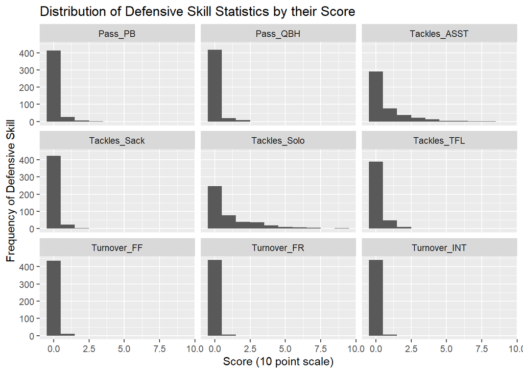

```r
defClean = defClean %>% gather(key = Statistic, value = score, 3:11)


ggplot(defClean, aes(x = defClean$score)) + geom_histogram(bins = 350, binwidth = 1) + facet_wrap(~Statistic) + labs(title = "Distribution of Defensive Skill Statistics by their Score", x = "Score (10 point scale)", y = "Frequency of Defensive Skill")
```

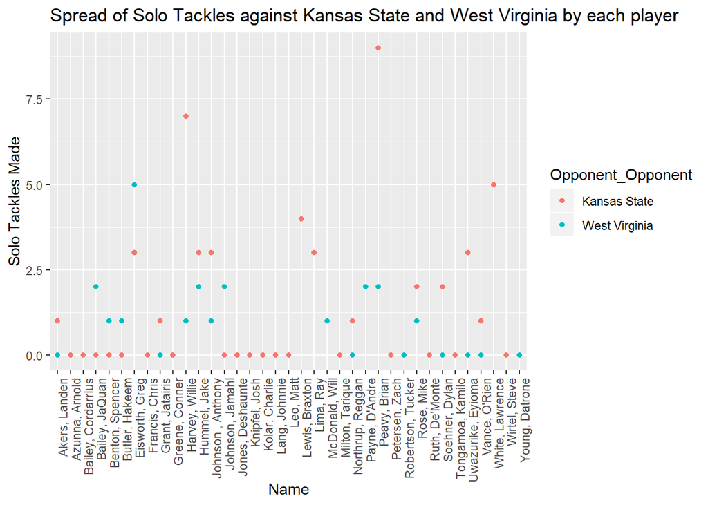

```r
dfWVKState <- defClean %>% filter((defClean$Opponent_Opponent == "West Virginia" & defClean$Statistic == "Tackles_Solo") |(defClean$Opponent_Opponent == "Kansas State" & defClean$Statistic == "Tackles_Solo" ))


#newDf <- data.frame(defKState$score)
#newDf <- newDf%>% mutate(KWVeTackles=defWV$score)

ggplot(dfWVKState, aes(x=Name, y=score, color = Opponent_Opponent)) + geom_point() + theme(axis.text.x =element_text(angle = 90, hjust= 1)) + labs(title = "Spread of Solo Tackles against Kansas State and West Virginia by each player", y = "Solo Tackles Made")+scale_fill_discrete(name = "Opponent")
```

Now we turn our attention to the player biography `bioClean`. First, we separate the `Hometown` column into two columns, namely the city and the state, and print the first few rows of these two columns. We separated the hometown by city and state, through using the same technique as before, all in part to the strsplit function, then using transform to create a new data frame that includes the city and state columns we created. We then grouped the players by their home state, and counted how many of the players hail from each state (see below).

```r
hometownSplit = strsplit(as.character(bioClean$Hometown), split = ", ")
newBioClean = transform(bioClean, city = sapply(hometownSplit, "[[", 1), state = sapply(hometownSplit, "[[", 2))
head(newBioClean)
```

```
##               Name       Position Weight              Class
## 1    Akers, Landen  Wide Receiver    192 Redshirt Sophomore
## 2     Allen, Chase      Tight End    240 Redshirt Sophomore
## 3       Alt, Gerry Offensive Line    290  Redshirt Freshman
## 4   Anderson, Cole      Tight End    250    Redshirt Senior
## 5 Assalley, Connor    Placekicker    191 Redshirt Sophomore
## 6    Austin, Aaron     Linebacker    205 Redshirt Sophomore
##             Hometown totalHeighInInches         city  state
## 1 Cedar Rapids, Iowa                 72 Cedar Rapids   Iowa
## 2          Nixa, Mo.                 79         Nixa    Mo.
## 3 Cedar Rapids, Iowa                 74 Cedar Rapids   Iowa
## 4 League City, Texas                 76  League City  Texas
## 5   Naperville, Ill.                 72   Naperville   Ill.
## 6     Walnut, Calif.                 71       Walnut Calif.
```

```r
newBioClean %>% group_by(newBioClean$state) %>% count()
```

```
## # A tibble: 25 x 2
## # Groups:   newBioClean$state [25]
##    `newBioClean$state`     n
##    <fct>               <int>
##  1 Ariz.                   3
##  2 Ark.                    2
##  3 Australia               2
##  4 Calif.                  8
##  5 D.C.                    1
##  6 Fla.                    8
##  7 Ga.                     2
##  8 Ill.                    5
##  9 Iowa                   44
## 10 Kan.                    3
## # ... with 15 more rows
```

## Part three: Joining data frames

The code below joins the offense and biography tables at an outer-left-join, and viewing the head will display hometowns, as well as cities and states individually.

```r
#joining the offensive player data together with the player biography
library(dplyr)
jointOffense<- left_join(offClean, newBioClean, by= "Name") #left joined the player biography onto the offense table
jointOffense<- jointOffense%>% group_by(Name)
head(jointOffense, 50)
```

```
## # A tibble: 50 x 19
## # Groups:   Name [4]
##    Name  Opponent_Oppone~ Receiving_REC Receiving_YDS Receiving_TD
##    <chr> <fct>                    <dbl>         <dbl>        <dbl>
##  1 Jone~ Iowa                         1            31            0
##  2 Jone~ Oklahoma                     9            66            0
##  3 Jone~ Akron                        6            39            0
##  4 Jone~ TCU                          3            23            0
##  5 Jone~ Oklahoma State               6            37            1
##  6 Jone~ West Virginia                1            32            1
##  7 Jone~ Texas Tech                   1             4            0
##  8 Jone~ Kansas                       4            31            0
##  9 Jone~ Baylor                       4            39            1
## 10 Jone~ Texas                        0             0            0
## # ... with 40 more rows, and 14 more variables: Rushing_ATT <dbl>,
## #   Rushing_YDS <dbl>, Rushing_TD <dbl>, `Passing_CMP-ATT` <dbl>,
## #   Passing_YDS <dbl>, Passing_TD <dbl>, Passing_INT <dbl>,
## #   Position <chr>, Weight <dbl>, Class <chr>, Hometown <chr>,
## #   totalHeighInInches <dbl>, city <fct>, state <fct>
```

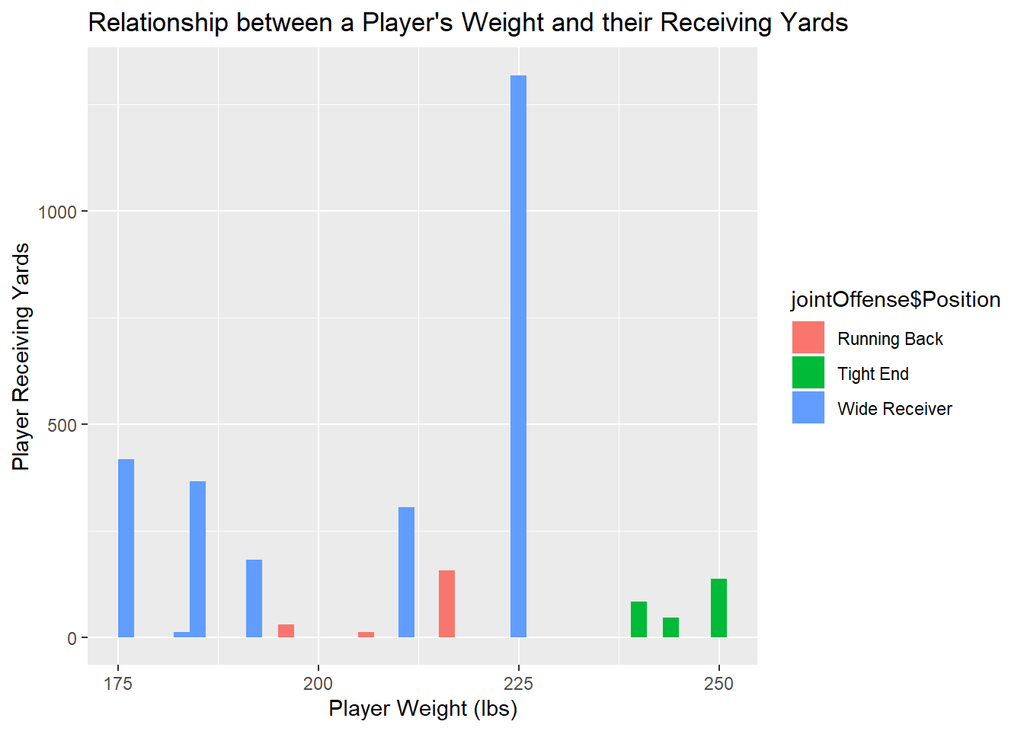

```r
#ggplot(jointOffense, aes(x = jointOffense$Weight, y = jointOffense$Receiving_YDS, color = jointOffense$Position)) + geom_point(position = "jitter") + labs(title = "Relationship between a Player's Weight and their Receiving Yards", x = "Player Weight (lbs)", y = "Player Receiving Yards")

ggplot(jointOffense, aes(x = jointOffense$Weight, y = jointOffense$Receiving_YDS, fill = jointOffense$Position, width = 2)) + geom_bar(stat = "identity") + labs(title = "Relationship between a Player's Weight and their Receiving Yards", x = "Player Weight (lbs)", y = "Player Receiving Yards")
```

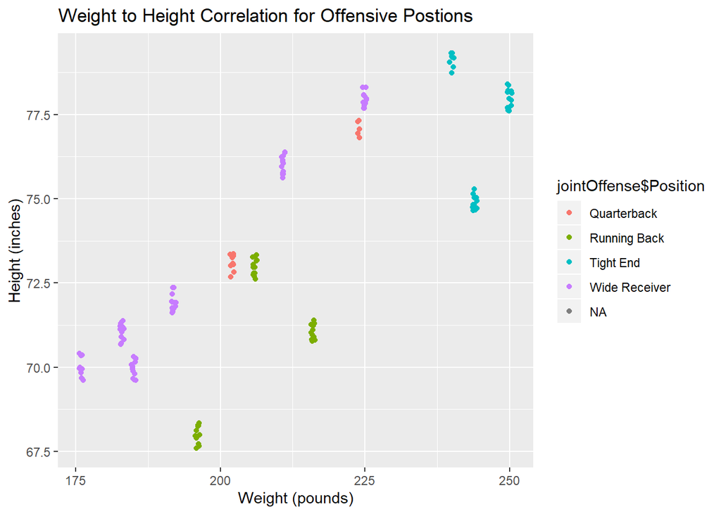

```r
ggplot(jointOffense, aes(x = jointOffense$Weight,  y = jointOffense$totalHeighInInches, color = jointOffense$Position)) + geom_point(position = "jitter") + labs(title = "Weight to Height Correlation for Offensive Postions", x = "Weight (pounds)", y = "Height (inches)")
```